# Part I - Prosper Loan Data Exploration

## Introduction

> This dataset contains 113,937 loans with 81 variables on each loan, including loan amount, borrower rate (or interest rate), current loan status, borrower income, and many others.

## Preliminary Wrangling

```python
# import all packages and set plots to be embedded inline
import numpy as np
import pandas as pd
import matplotlib.pyplot as plt
import seaborn as sb
import datetime

%matplotlib inline
```

> Load in your dataset and describe its properties through the questions below. Try and motivate your exploration goals through this section.

```python
# load in the dataset into a pandas dataframe, print five samples
loans_df = pd.read_csv('prosperLoanData.csv')
loans_df.sample(5)
```

|  | ListingKey | ListingNumber | ListingCreationDate | CreditGrade | Term | LoanStatus | ClosedDate | BorrowerAPR | BorrowerRate | LenderYield | ... | LP_ServiceFees | LP_CollectionFees | LP_GrossPrincipalLoss | LP_NetPrincipalLoss | LP_NonPrincipalRecoverypayments | PercentFunded | Recommendations | InvestmentFromFriendsCount | InvestmentFromFriendsAmount | Investors |
| --- | --- | --- | --- | --- | --- | --- | --- | --- | --- | --- | --- | --- | --- | --- | --- | --- | --- | --- | --- | --- | --- |
| 3859 | 6AB93599281345523EADE8E | 1126791 | 2014-01-08 13:12:35.123000000 | NaN | 36 | Current | NaN | 0.29414 | 0.2554 | 0.2454 | ... | -2.97 | 0.0 | 0.0 | 0.0 | 0.0 | 1.0 | 0 | 0 | 0.0 | 1 |
| 19142 | F9543582048206190A233A9 | 805504 | 2013-06-11 14:02:41.970000000 | NaN | 36 | Current | NaN | 0.20053 | 0.1639 | 0.1539 | ... | -216.60 | 0.0 | 0.0 | 0.0 | 0.0 | 1.0 | 0 | 0 | 0.0 | 139 |
| 41553 | 4FA73519635170852228F8A | 512584 | 2011-06-22 20:10:48.997000000 | NaN | 36 | Completed | 2012-04-04 00:00:00 | 0.30532 | 0.2699 | 0.2599 | ... | -52.43 | 0.0 | 0.0 | 0.0 | 0.0 | 1.0 | 0 | 0 | 0.0 | 109 |
| 67935 | DE9F3576072990852083E61 | 751563 | 2013-04-12 07:18:00.950000000 | NaN | 60 | Current | NaN | 0.16499 | 0.1419 | 0.1319 | ... | -91.23 | 0.0 | 0.0 | 0.0 | 0.0 | 1.0 | 0 | 0 | 0.0 | 3 |
| 55305 | E02535667504445474B6875 | 692917 | 2013-01-01 10:14:33.947000000 | NaN | 36 | Current | NaN | 0.30285 | 0.2639 | 0.2539 | ... | -38.10 | 0.0 | 0.0 | 0.0 | 0.0 | 1.0 | 0 | 0 | 0.0 | 56 |

5 rows × 81 columns

```python
# high-level overview of the original data shape and metadata
print(loans_df.shape)
print(loans_df.info())
```

```
(113937, 81)
<class 'pandas.core.frame.DataFrame'>
RangeIndex: 113937 entries, 0 to 113936
Data columns (total 81 columns):
 #   Column                               Non-Null Count   Dtype
---  ------                               --------------   -----
 0   ListingKey                           113937 non-null  object
 1   ListingNumber                        113937 non-null  int64
 2   ListingCreationDate                  113937 non-null  object
 3   CreditGrade                          28953 non-null   object
 4   Term                                 113937 non-null  int64
 5   LoanStatus                           113937 non-null  object
 6   ClosedDate                           55089 non-null   object
 7   BorrowerAPR                          113912 non-null  float64
 8   BorrowerRate                         113937 non-null  float64
```

[output cut: 75 more lines]

> **Note**: The dataset contains 81 columns and only the columns relevant to the analysis will be selected. The following 16 columns will be used for this project:
> - ListingCreationDate
> - ListingCategory (numeric)
> - Term
> - LoanStatus
> - BorrowerRate
> - BorrowerAPR
> - ProsperRating (Alpha)
> - ProsperScore
> - BorrowerState
> - Occupation
> - EmploymentStatus
> - IsBorrowerHomeowner
> - DebtToIncomeRatio
> - IncomeRange
> - LoanOriginalAmount
> - MonthlyLoanPayment

```python
#select columns in the data that are relevant to my analysis
loan_cols = ['ListingCreationDate','ListingCategory (numeric)','Term','LoanStatus', 'BorrowerRate','BorrowerAPR' ,'ProsperRating (Alpha)','ProsperScore', 'BorrowerState',
             'Occupation','EmploymentStatus','IsBorrowerHomeowner','DebtToIncomeRatio', 'IncomeRange', 'LoanOriginalAmount','MonthlyLoanPayment']
loan_data = loans_df[loan_cols]
loan_data.head()
```

|  | ListingCreationDate | ListingCategory (numeric) | Term | LoanStatus | BorrowerRate | BorrowerAPR | ProsperRating (Alpha) | ProsperScore | BorrowerState | Occupation | EmploymentStatus | IsBorrowerHomeowner | DebtToIncomeRatio | IncomeRange | LoanOriginalAmount | MonthlyLoanPayment |
| --- | --- | --- | --- | --- | --- | --- | --- | --- | --- | --- | --- | --- | --- | --- | --- | --- |
| 0 | 2007-08-26 19:09:29.263000000 | 0 | 36 | Completed | 0.1580 | 0.16516 | NaN | NaN | CO | Other | Self-employed | True | 0.17 | $25,000-49,999 | 9425 | 330.43 |
| 1 | 2014-02-27 08:28:07.900000000 | 2 | 36 | Current | 0.0920 | 0.12016 | A | 7.0 | CO | Professional | Employed | False | 0.18 | $50,000-74,999 | 10000 | 318.93 |
| 2 | 2007-01-05 15:00:47.090000000 | 0 | 36 | Completed | 0.2750 | 0.28269 | NaN | NaN | GA | Other | Not available | False | 0.06 | Not displayed | 3001 | 123.32 |
| 3 | 2012-10-22 11:02:35.010000000 | 16 | 36 | Current | 0.0974 | 0.12528 | A | 9.0 | GA | Skilled Labor | Employed | True | 0.15 | $25,000-49,999 | 10000 | 321.45 |
| 4 | 2013-09-14 18:38:39.097000000 | 2 | 36 | Current | 0.2085 | 0.24614 | D | 4.0 | MN | Executive | Employed | True | 0.26 | $100,000+ | 15000 | 563.97 |

```python
#random samples of the data
loan_data.sample(10)
```

|  | ListingCreationDate | ListingCategory (numeric) | Term | LoanStatus | BorrowerRate | BorrowerAPR | ProsperRating (Alpha) | ProsperScore | BorrowerState | Occupation | EmploymentStatus | IsBorrowerHomeowner | DebtToIncomeRatio | IncomeRange | LoanOriginalAmount | MonthlyLoanPayment |
| --- | --- | --- | --- | --- | --- | --- | --- | --- | --- | --- | --- | --- | --- | --- | --- | --- |
| 91927 | 2007-06-12 12:14:07.430000000 | 0 | 36 | Defaulted | 0.2500 | 0.25757 | NaN | NaN | CA | Realtor | Self-employed | True | 0.29000 | $100,000+ | 25000 | 994.00 |
| 21966 | 2007-02-02 18:59:53.883000000 | 0 | 36 | Defaulted | 0.2325 | 0.23999 | NaN | NaN | CA | Skilled Labor | Not available | True | 0.03000 | Not displayed | 3000 | 116.52 |
| 75550 | 2006-06-09 17:27:11.937000000 | 0 | 36 | Defaulted | 0.1150 | 0.12198 | NaN | NaN | AZ | NaN | NaN | True | 0.16000 | Not displayed | 5000 | 164.88 |
| 6016 | 2013-10-11 05:20:06.327000000 | 1 | 36 | Current | 0.0990 | 0.12691 | A | 8.0 | CO | Accountant/CPA | Employed | True | 0.25000 | $50,000-74,999 | 5000 | 161.10 |
| 4023 | 2007-10-02 20:32:05.750000000 | 0 | 36 | Completed | 0.1600 | 0.16717 | NaN | NaN | IL | Sales - Retail | Part-time | False | 0.16000 | $1-24,999 | 3000 | 103.65 |
| 60281 | 2010-07-01 18:07:40.733000000 | 1 | 36 | Completed | 0.2625 | 0.28574 | D | 7.0 | PA | Sales - Retail | Full-time | False | 0.50000 | $1-24,999 | 2000 | 80.85 |
| 54406 | 2009-09-09 07:40:49.590000000 | 3 | 36 | Completed | 0.0940 | 0.11499 | AA | 9.0 | PA | Accountant/CPA | Full-time | True | 0.13000 | $75,000-99,999 | 4900 | 156.73 |
| 92345 | 2006-04-08 05:14:30.423000000 | 0 | 36 | Defaulted | 0.1900 | 0.19730 | NaN | NaN | NaN | NaN | NaN | False | 0.06055 | Not displayed | 5000 | 183.28 |
| 72686 | 2010-08-05 20:45:33.110000000 | 1 | 36 | Completed | 0.2575 | 0.29265 | D | 7.0 | CA | Professional | Employed | False | 0.14000 | $25,000-49,999 | 4500 | 180.71 |
| 78211 | 2006-08-02 01:06:33.510000000 | 0 | 36 | Defaulted | 0.1849 | 0.19218 | NaN | NaN | CA | Other | Not available | True | 0.18000 | Not displayed | 25000 | 909.97 |

```python
# high-level overview of the selected data shape and datatypes
print(loan_data.shape)
print(loan_data.dtypes)
```

```
(113937, 16)
ListingCreationDate           object
ListingCategory (numeric)      int64
Term                           int64
LoanStatus                    object
BorrowerRate                 float64
BorrowerAPR                  float64
ProsperRating (Alpha)         object
ProsperScore                 float64
BorrowerState                 object
Occupation                    object
EmploymentStatus              object
IsBorrowerHomeowner             bool
DebtToIncomeRatio            float64
IncomeRange                   object
LoanOriginalAmount             int64
MonthlyLoanPayment           float64
dtype: object
```

### Assessing and cleaning data

> In this section, i will assess the dataset to understand its structure, determine feature(s) of interest, discover quality issues and clean these issues before performing exploratory analysis.

```python
#view metadata
loan_data.info()
```

```
<class 'pandas.core.frame.DataFrame'>
RangeIndex: 113937 entries, 0 to 113936
Data columns (total 16 columns):
 #   Column                     Non-Null Count   Dtype
---  ------                     --------------   -----
 0   ListingCreationDate        113937 non-null  object
 1   ListingCategory (numeric)  113937 non-null  int64
 2   Term                       113937 non-null  int64
 3   LoanStatus                 113937 non-null  object
 4   BorrowerRate               113937 non-null  float64
 5   BorrowerAPR                113912 non-null  float64
 6   ProsperRating (Alpha)      84853 non-null   object
 7   ProsperScore               84853 non-null   float64
 8   BorrowerState              108422 non-null  object
 9   Occupation                 110349 non-null  object
 10  EmploymentStatus           111682 non-null  object
 11  IsBorrowerHomeowner        113937 non-null  bool
 12  DebtToIncomeRatio          105383 non-null  float64
 13  IncomeRange                113937 non-null  object
 14  LoanOriginalAmount         113937 non-null  int64
 15  MonthlyLoanPayment         113937 non-null  float64
dtypes: bool(1), float64(5), int64(3), object(7)
memory usage: 13.1+ MB
```

```python
#select only the observations with Prosper Ratings (i.e. remove rows with missing ProsperRating (Alpha))
loan_data = loan_data[loan_data['ProsperRating (Alpha)'].notnull()]
```

```python
#view metadata
loan_data.info()
```

```
<class 'pandas.core.frame.DataFrame'>
Int64Index: 84853 entries, 1 to 113936
Data columns (total 16 columns):
 #   Column                     Non-Null Count  Dtype
---  ------                     --------------  -----
 0   ListingCreationDate        84853 non-null  object
 1   ListingCategory (numeric)  84853 non-null  int64
 2   Term                       84853 non-null  int64
 3   LoanStatus                 84853 non-null  object
 4   BorrowerRate               84853 non-null  float64
 5   BorrowerAPR                84853 non-null  float64
 6   ProsperRating (Alpha)      84853 non-null  object
 7   ProsperScore               84853 non-null  float64
 8   BorrowerState              84853 non-null  object
 9   Occupation                 83520 non-null  object
 10  EmploymentStatus           84853 non-null  object
 11  IsBorrowerHomeowner        84853 non-null  bool
 12  DebtToIncomeRatio          77557 non-null  float64
 13  IncomeRange                84853 non-null  object
 14  LoanOriginalAmount         84853 non-null  int64
 15  MonthlyLoanPayment         84853 non-null  float64
dtypes: bool(1), float64(5), int64(3), object(7)
memory usage: 10.4+ MB
```

> **Observations:**
> - Only two columns (Occupation and DebtToIncomeRatio) have missing values.
> - Some columns have wrong datatypes (e.g ListingCreationDate is object instead of datetime
> - The numeric categories in ListingCategory (numeric) column are unclear.

```python
#Fill blank values in the DebtToIncomeRatio column with the mean value
loan_data['DebtToIncomeRatio'] = loan_data['DebtToIncomeRatio'].fillna(loan_data['DebtToIncomeRatio'].mean())
```

```python
#Fill missing values in the Occupation column with 'Unspecified'
loan_data['Occupation'] = loan_data['Occupation'].fillna('Unspecified')
```

```python
#Change ListingCreationDate to datetime datatype
loan_data['ListingCreationDate'] = pd.to_datetime(loan_data['ListingCreationDate'])
```

```python
#Change Term to object datatype
loan_data['Term'] = loan_data['Term'].astype(str)
```

```python
loan_data['ListingCategory (numeric)'].unique()
```

```
array([ 2, 16,  1,  7, 13,  6, 15, 20, 19, 18,  3,  8, 11, 14,  9, 17, 10,
        0,  5, 12], dtype=int64)
```

> **Labels for the numeric categories:** 0 - Not Available, 1 - Debt Consolidation, 2 - Home Improvement, 3 - Business, 4 - Personal Loan, 5 - Student Use, 6 - Auto, 7- Other, 8 - Baby&Adoption, 9 - Boat, 10 - Cosmetic Procedure, 11 - Engagement Ring, 12 - Green Loans, 13 - Household Expenses, 14 - Large Purchases, 15 - Medical/Dental, 16 - Motorcycle, 17 - RV, 18 - Taxes, 19 - Vacation, 20 - Wedding Loans

```python
#Replace the numeric categories in 'ListingCategory (numeric)' column to their corresponding labels for easy analysis
label_categories = {"ListingCategory (numeric)":   {0: 'Not Available', 1: 'Debt Consolidation', 2: 'Home Improvement',
                      3: 'Business', 4: 'Personal Loan', 5: 'Student Use', 6: 'Auto', 7: 'Other', 8: 'Baby&Adoption',
                      9: 'Boat', 10: 'Cosmetic Procedure', 11: 'Engagement Ring', 12: 'Green Loans', 13:'Household Expenses',
                      14:'Large Purchases', 15: 'Medical/Dental', 16:'Motorcycle', 17: 'RV', 18:'Taxes', 19:'Vacation',
                      20:'Wedding Loans'}}
loan_data = loan_data.replace(label_categories)
```

```python
#unique listing categories
loan_data['ListingCategory (numeric)'].unique()
```

```
array(['Home Improvement', 'Motorcycle', 'Debt Consolidation', 'Other',
       'Household Expenses', 'Auto', 'Medical/Dental', 'Wedding Loans',
       'Vacation', 'Taxes', 'Business', 'Baby&Adoption',
       'Engagement Ring', 'Large Purchases', 'Boat', 'RV',
       'Cosmetic Procedure', 'Not Available', 'Student Use',
       'Green Loans'], dtype=object)
```

```python
#rename the 'ListingCategory (numeric)' column to 'ListingCategory'
loan_data.rename(columns = {'ListingCategory (numeric)':'ListingCategory'}, inplace = True)
```

```python
loan_data.info()
```

```
<class 'pandas.core.frame.DataFrame'>
Int64Index: 84853 entries, 1 to 113936
Data columns (total 16 columns):
 #   Column                 Non-Null Count  Dtype
---  ------                 --------------  -----
 0   ListingCreationDate    84853 non-null  datetime64[ns]
 1   ListingCategory        84853 non-null  object
 2   Term                   84853 non-null  object
 3   LoanStatus             84853 non-null  object
 4   BorrowerRate           84853 non-null  float64
 5   BorrowerAPR            84853 non-null  float64
 6   ProsperRating (Alpha)  84853 non-null  object
 7   ProsperScore           84853 non-null  float64
 8   BorrowerState          84853 non-null  object
 9   Occupation             84853 non-null  object
 10  EmploymentStatus       84853 non-null  object
 11  IsBorrowerHomeowner    84853 non-null  bool
 12  DebtToIncomeRatio      84853 non-null  float64
 13  IncomeRange            84853 non-null  object
 14  LoanOriginalAmount     84853 non-null  int64
 15  MonthlyLoanPayment     84853 non-null  float64
dtypes: bool(1), datetime64[ns](1), float64(5), int64(1), object(8)
memory usage: 10.4+ MB
```

```python
# descriptive statistics for numeric variables
loan_data.describe()
```

|  | BorrowerRate | BorrowerAPR | ProsperScore | DebtToIncomeRatio | LoanOriginalAmount | MonthlyLoanPayment |
| --- | --- | --- | --- | --- | --- | --- |
| count | 84853.000000 | 84853.000000 | 84853.000000 | 84853.000000 | 84853.000000 | 84853.000000 |
| mean | 0.196022 | 0.226658 | 5.950067 | 0.258752 | 9083.440515 | 291.930720 |
| std | 0.074631 | 0.079916 | 2.376501 | 0.304333 | 6287.860058 | 186.678314 |
| min | 0.040000 | 0.045830 | 1.000000 | 0.000000 | 1000.000000 | 0.000000 |
| 25% | 0.135900 | 0.163280 | 4.000000 | 0.160000 | 4000.000000 | 157.330000 |
| 50% | 0.187500 | 0.219450 | 6.000000 | 0.240000 | 7500.000000 | 251.940000 |
| 75% | 0.257400 | 0.292540 | 8.000000 | 0.310000 | 13500.000000 | 388.350000 |
| max | 0.360000 | 0.423950 | 11.000000 | 10.010000 | 35000.000000 | 2251.510000 |

### What is the structure of your dataset?

> The original dataset contains 113,937 entries (rows) and 81 features (columns). However, after assessing and cleaning the data, it now contains 84853 entries and 16 features. The features consist of 1 boolean, 1 integer, 5 float, 8 object and 1 datetime data types.

### What is/are the main feature(s) of interest in your dataset?

> My main features of interest in the data are:
> - Distribution of loan characteristics .
> - The main factors affecting borrowers' risk score and annual percentage rate.

### What features in the dataset do you think will help support your investigation into your feature(s) of interest?

> The features that will help support my exploration are: ListingCreationDate, LoanStatus, BorrowerAPR, ProsperScore, BorrowerState, Occupation, EmploymentStatus,IsBorrowerHomeowner, DebtToIncomeRatio, ProsperRating (Alpha), IncomeRange etc.

## Univariate Exploration

> In this section, I would be carrying out univariate explorations on the BorrowerAPR, ProsperScore, EmploymentStatus, LoanStatus, IncomeRange, ProsperRating (Alpha) and DebtToIncomeRatio columns.

### What is the distribution of BorrowerAPR?

```python
#summary statistics
loan_data['BorrowerAPR'].describe()
```

```
count    84853.000000
mean         0.226658
std          0.079916
min          0.045830
25%          0.163280
50%          0.219450
75%          0.292540
max          0.423950
Name: BorrowerAPR, dtype: float64
```

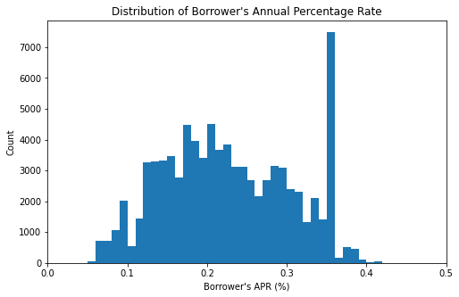

```python
#plot histogram of BorrowerAPR
plt.figure(figsize=(8,5))
binsize = 0.01
bins = np.arange(0, loan_data['BorrowerAPR'].max()+0.05, binsize)
plt.hist(data = loan_data, x = 'BorrowerAPR', bins = bins)
plt.xlabel("Borrower's APR (%)")
plt.ylabel('Count')
plt.title("Distribution of Borrower's Annual Percentage Rate")
plt.xlim(0,0.5);
```

### What is the distribution of ProsperScore?

```python
#summary of descriptive statistics
loan_data['ProsperScore'].describe()
```

```
count    84853.000000
mean         5.950067
std          2.376501
min          1.000000
25%          4.000000
50%          6.000000
75%          8.000000
max         11.000000
Name: ProsperScore, dtype: float64
```

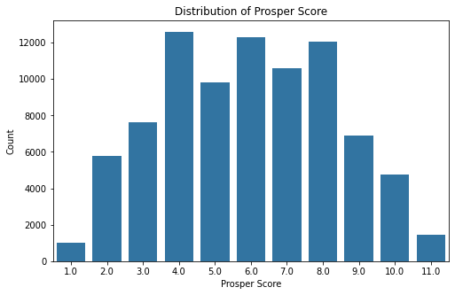

```python
#plot distribution of ProsperScore
plt.figure(figsize=(8,5))
color = sb.color_palette()[0]
sb.countplot(data=loan_data, x='ProsperScore', color=color)
plt.xlabel('Prosper Score')
plt.ylabel('Count')
plt.title('Distribution of Prosper Score');
```

> **Interpretation:** The figure above shows the prosper score of borrowers. The score ranges from 1-11, with 11 being the best, or lowest risk score. The top prosper scores are: 4.0, 6.0 and 8.0.

### What is the distribution of EmploymentStatus?

```python
#counts of distinct values
freq = loan_data['EmploymentStatus'].value_counts()
```

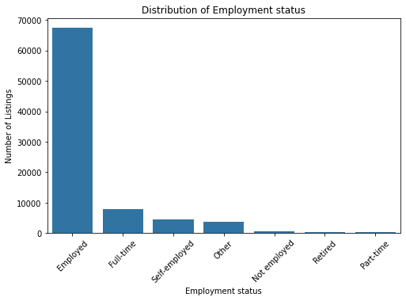

```python
#plot distribution of employment status
plt.figure(figsize=(8,5))
color_base = sb.color_palette()[0]
emp_order = freq.index
sb.countplot(data=loan_data, x='EmploymentStatus', color=color_base, order=emp_order)
plt.xticks(rotation=45)
plt.xlabel('Employment status')
plt.ylabel('Number of Listings')
plt.title('Distribution of Employment status');
```

### What is the distribution of Loan Status?

```python
#counts of distinct values
loan_data['LoanStatus'].value_counts()
```

```
Current                   56576
Completed                 19664
Chargedoff                 5336
Defaulted                  1005
Past Due (1-15 days)        806
Past Due (31-60 days)       363
Past Due (61-90 days)       313
Past Due (91-120 days)      304
Past Due (16-30 days)       265
FinalPaymentInProgress      205
Past Due (>120 days)         16
Name: LoanStatus, dtype: int64
```

```python
#group all the 'past due' loans
loan_data['LoanStatus'] = loan_data['LoanStatus'].apply(lambda x: x if 'Past Due' not in x else 'Past Due')
```

```python
freq = loan_data['LoanStatus'].value_counts()
```

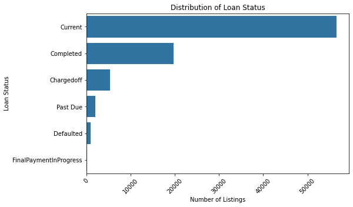

```python
#plot distribution
plt.figure(figsize=(8,5))
status_order = freq.index
sb.countplot(data=loan_data, y='LoanStatus', color=color, order=status_order);
plt.xticks(rotation = 45)
plt.xlabel('Number of Listings')
plt.ylabel('Loan Status')
plt.title('Distribution of Loan Status');
```

> **Interpretation:** The figure above indicates that most borrowers' loan status are *Current* (i.e. in progress) then *Completed*.

### What is the distribution of IncomeRange?

```python
#counts of distinct values
loan_data['IncomeRange'].value_counts()
```

```
$50,000-74,999    25627
$25,000-49,999    24175
$100,000+         15205
$75,000-99,999    14498
$1-24,999          4654
Not employed        649
$0                   45
Name: IncomeRange, dtype: int64
```

```python
#order income ranges and convert to ordinal data type
ordered_income = ['Not Employed', '$0', '$1-24,999', '$25,000-49,999', '$50,000-74,999', '$75,000-99,999', '$100,000+']
ordered_var = pd.api.types.CategoricalDtype(ordered = True,
                                                categories = ordered_income)
loan_data['IncomeRange'] = loan_data['IncomeRange'].astype(ordered_var)
```

[output not shown]

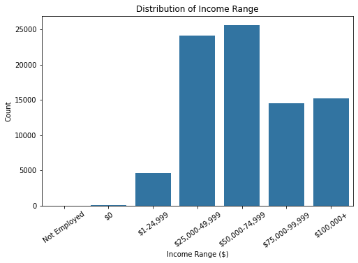

```python
#plot distribution
plt.figure(figsize=(8,5))
sb.countplot(data=loan_data, x='IncomeRange', color=color);
plt.ylabel('Count')
plt.xlabel('Income Range ($)')
plt.title('Distribution of Income Range');
plt.xticks(rotation=35)
```

> **Interpretation:** The figure above shows the distribution of income ranges of borrowers. Most borrowers fall within the income range of *$50,000-74,999*

### What is the distribution of Term?

```python
#add the string'months' to the loan terms
loan_data['Term'] = loan_data['Term'].astype(str) + ' months'
```

```python
#counts of distinct values
loan_data['Term'].value_counts()
```

```
36 months    58695
60 months    24545
12 months     1613
Name: Term, dtype: int64
```

```python
#order the loan terms and convert to ordinal data
ordered_term = ['12 months','36 months', '60 months']
ordered_var = pd.api.types.CategoricalDtype(ordered = True,
                                                categories = ordered_term)
loan_data['Term'] = loan_data['Term'].astype(ordered_var)
```

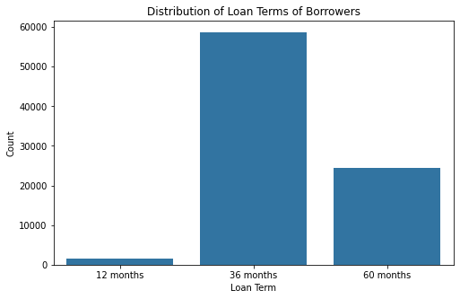

```python
#plot distribution
plt.figure(figsize=(8,5))
sb.countplot(data=loan_data, x='Term', color=color);
plt.ylabel('Count')
plt.xlabel('Loan Term')
plt.title('Distribution of Loan Terms of Borrowers');
```

> **Interpretation:** The figure above shows the distribution of loan terms of borrowers. The most common loan term is *36* months.

### What is the distribution of ProsperRating (Alpha)?

```python
#counts of distinct values
loan_data['ProsperRating (Alpha)'].value_counts()
```

```
C     18345
B     15581
A     14551
D     14274
E      9795
HR     6935
AA     5372
Name: ProsperRating (Alpha), dtype: int64
```

```python
#order prosper ratings and convert to ordinal data
ordered_rating = ['HR','E','D','C','B','A','AA']
ordered_var = pd.api.types.CategoricalDtype(ordered = True,
                                                categories = ordered_rating)
loan_data['ProsperRating (Alpha)'] = loan_data['ProsperRating (Alpha)'].astype(ordered_var)
```

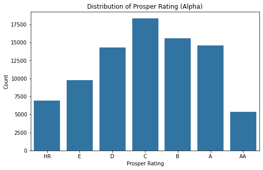

```python
#plot distribution
plt.figure(figsize=(8,5))
sb.countplot(data=loan_data, x='ProsperRating (Alpha)', color=color);
plt.ylabel('Count')
plt.xlabel('Prosper Rating')
plt.title('Distribution of Prosper Rating (Alpha)');
```

> **Interpretation:** The figure above shows the distribution of prosper alpha ratings. Most listings have a rating of *'C'* then *'B'*.

### What is the distribution of DebtToIncome Ratio?

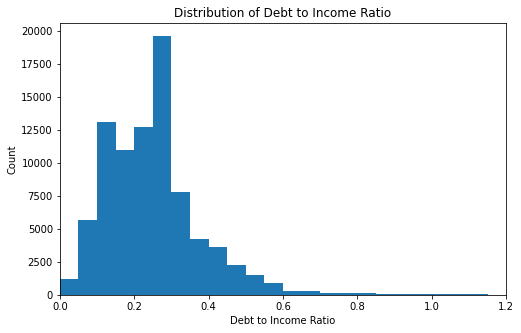

```python
#plot distribution
plt.figure(figsize=(8,5))
binsize = 0.05
bins = np.arange(0, loan_data['DebtToIncomeRatio'].max()+binsize, binsize)
plt.hist(data = loan_data, x = 'DebtToIncomeRatio', bins = bins)
plt.xlabel('Debt to Income Ratio')
plt.ylabel('Count')
plt.title('Distribution of Debt to Income Ratio')
plt.xlim(0,1.2);
```

> **Interpretation:** A higher debt to income ratio indicates that the borrower has a higher debt compared to the income. In this figure, most borrowers have a debt to income ratio of about 0.3 (30%).

### Of the features you investigated, were there any unusual distributions? Did you perform any operations on the data to tidy, adjust, or change the form of the data? If so, why did you do this?

> No, there were no unusual distributions. My primary focus in terms of data transformation of categorical variables is to transform categorical variables into category data type for easy analysis.

## Bivariate Exploration

> In this section, I will investigate relationships between pairs of variables selected for the exploratory analysis. This involved the following bivariate exploration:
> - Quantitative and Quantitative analysis
> - Qualitative and Quantitative analysis
> - Qualitative and Qualitative analysis

```python
#get columns of the dataset
loan_data.columns
```

```
Index(['ListingCreationDate', 'ListingCategory', 'Term', 'LoanStatus',
       'BorrowerRate', 'BorrowerAPR', 'ProsperRating (Alpha)', 'ProsperScore',
       'BorrowerState', 'Occupation', 'EmploymentStatus',
       'IsBorrowerHomeowner', 'DebtToIncomeRatio', 'IncomeRange',
       'LoanOriginalAmount', 'MonthlyLoanPayment'],
      dtype='object')
```

```python
#Numerical variables of interest
num_var = ['DebtToIncomeRatio','LoanOriginalAmount','MonthlyLoanPayment', 'ProsperScore', 'BorrowerAPR' ]

#Categorical variables of interest
categorical_var = ['Term', 'ProsperRating (Alpha)', 'EmploymentStatus', 'IncomeRange', 'ListingCategory', 'LoanStatus']
```

### Quantitative and Quantitative analysis

#### Which combination of quantitative variables are highly correlated?

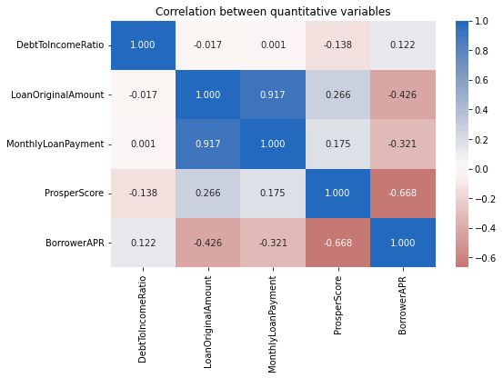

```python
# correlation plot
plt.figure(figsize = [8, 5])
sb.heatmap(loan_data[num_var].corr(), annot = True, fmt = '.3f',
           cmap = 'vlag_r', center = 0);
plt.title("Correlation between quantitative variables")
plt.show()
```

> **Interpretation:** The combination of quanitative variables that are highly correlated are:
> - LoanOriginalAmount and MonthlyLoanPayment (positive correlation): 0.917
> - ProsperScore and BorrowerAPR (negative correlation): -0.668

#### Is there an association between the quantitative variables?

```
loan_data.shape= (84853, 16)
sample.shape= (5000, 16)
```

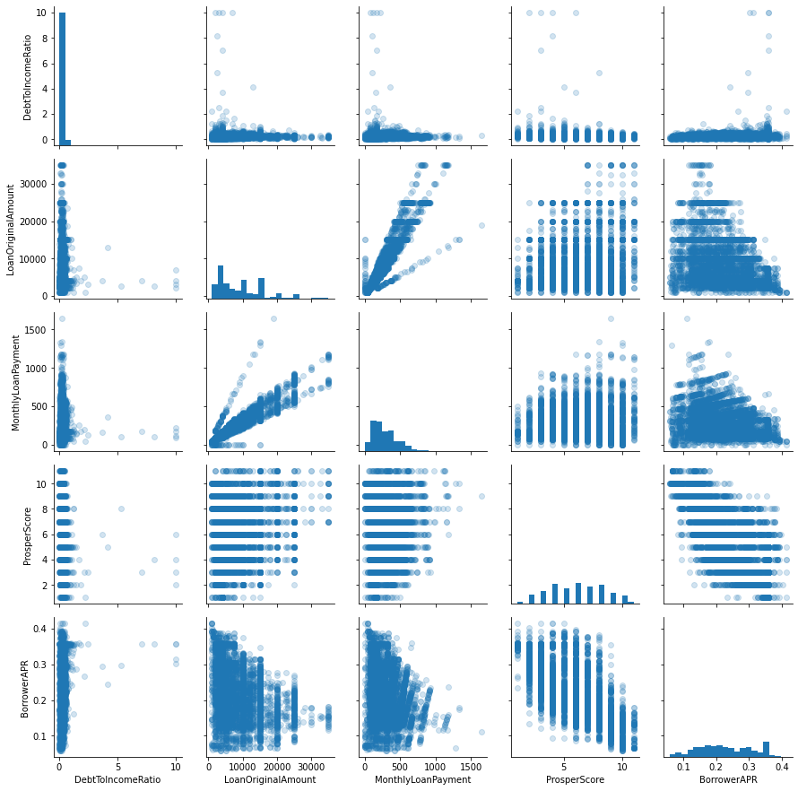

```python
# plot matrix: sample 5000 loans so that plots are clearer and they render faster
print("loan_data.shape=",loan_data.shape)
sample = loan_data.sample(n=5000, replace = False)
print("sample.shape=",sample.shape)

g = sb.PairGrid(data = sample, vars = num_var)
g = g.map_diag(plt.hist, bins = 20);
g.map_offdiag(plt.scatter, alpha=0.2)
```

> **Interpretation:**
> - There is a positive association between LoanOriginalAmount and MonthlyLoanPayment (with a correlation coefficient of 0.917).
> - There is a negative association between ProsperScore and BorrowerAPR (correlation coefficient = -0.668).
> - Most of the remaining variables do not present a strong correlation.

### Qualitative and Quantitative analysis

#### What is the monthly number of loan listings?

```python
#create a new column 'Month' for the month names of the ListingCreationDate
loan_data['Month'] = loan_data['ListingCreationDate'].dt.month_name()
loan_data['Month'].value_counts()
```

```
January      9201
October      8728
December     8441
November     8245
February     7963
September    7625
July         6638
August       6443
June         5808
May          5470
March        5385
April        4906
Name: Month, dtype: int64
```

```python
#order the month names
ordered_month = ['January','February','March','April','May','June','July','August','September','October', 'November', 'December']
ordered_var = pd.api.types.CategoricalDtype(ordered = True,
                                                categories = ordered_month)
```

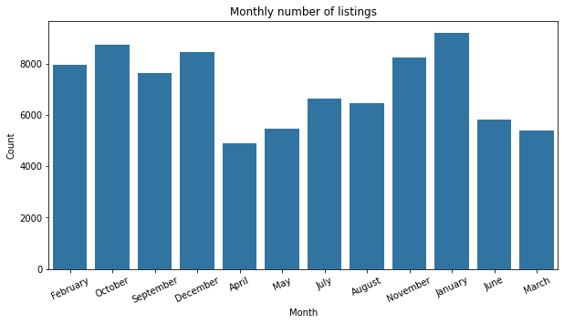

```python
#plot distribution of loan listings by months
fig, ax = plt.subplots(figsize=(10,5))
#ax.set(yscale="log")
sb.countplot(data = loan_data, x = 'Month', color=color)
plt.xticks(rotation=25)
plt.ylabel('Count')
plt.title('Monthly number of listings');
```

> **Interpretation:** Most of the loan listings (over 9000) were created in January then October then December.

#### Which of the selected categorical variables affect BorrowerAPR, ProsperScore and LoanOriginalAmount?

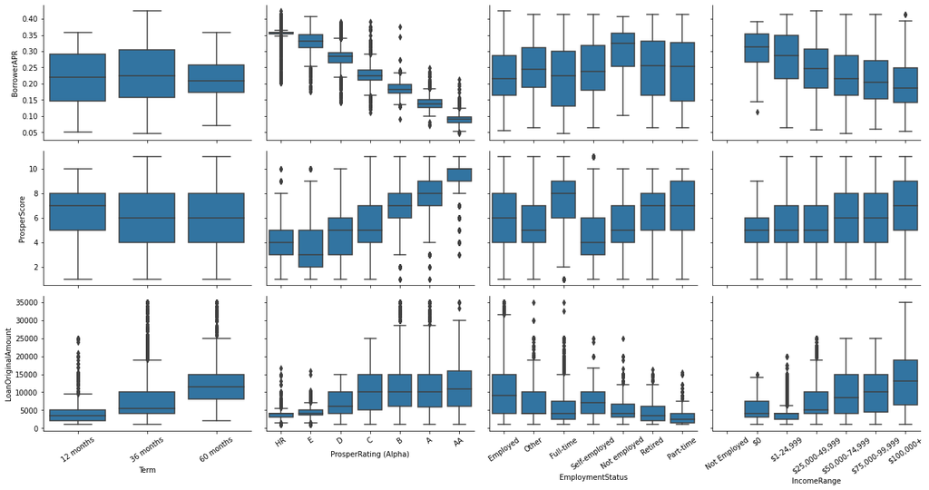

```python
# plot matrix of numeric features against categorical features.
# can use a larger sample since there are fewer plots and they're simpler in nature.


def boxgrid(x, y, **kwargs):
    """ Quick hack for creating box plots with seaborn's PairGrid. """
    default_color = sb.color_palette()[0]
    sb.boxplot(x=x, y=y, color=default_color)
    plt.xticks(rotation = 35)

plt.figure(figsize = [10, 10])
g = sb.PairGrid(data = loan_data, y_vars = ['BorrowerAPR','ProsperScore', 'LoanOriginalAmount'], x_vars = categorical_var[0:4],
                height = 3, aspect = 1.5)
g.map(boxgrid);
```

> **Interpretations:**
> - Higher loan amounts (i.e. LoanOriginalAmount) result in longer loan terms (i.e. Term)
> - The higher the prosper rating, the lower the Borrower's Annual Percentage Rate (APR).
> - Borrowers with higher income ranges tend to have lower APR.

### Qualitative and Qualitative analysis

> In this section, I will be exploring and plotting qualitative variables against qualitative variables

#### Is there an association between EmploymentStatus and LoanStatus?

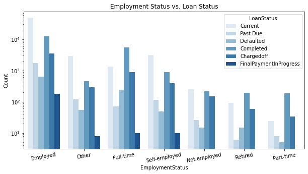

```python
#plot bivariate analysis of two qualitative variables
fig, ax = plt.subplots(figsize=(10,5))
ax.set(yscale="log")
sb.countplot(data = loan_data, x = 'EmploymentStatus', ax=ax, hue = 'LoanStatus', palette = 'Blues')
plt.xticks(rotation=10)
plt.ylabel('Count')
plt.title('Employment Status vs. Loan Status');
```

Most borrowers are employed and full-time. A high number of employed borrowers completed their loan payments compared to unemployed and retired borrowers. However, there is no a direct association between employment status and loan status

#### Is their an association between IncomeRange and LoanStatus?

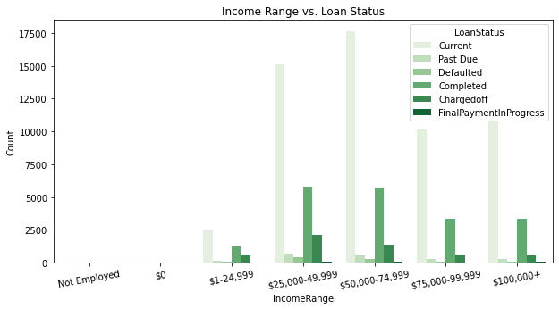

```python
#plot bivariate analysis of two qualitative variables
fig, ax = plt.subplots(figsize=(10,5))
#ax.set(yscale="log")
sb.countplot(data = loan_data, x = 'IncomeRange', ax=ax, hue = 'LoanStatus', palette = 'Greens')
plt.xticks(rotation=10)
plt.ylabel('Count')
plt.title('Income Range vs. Loan Status');
```

#### Is there an association between ProsperRating (Alpha) and LoanStatus?

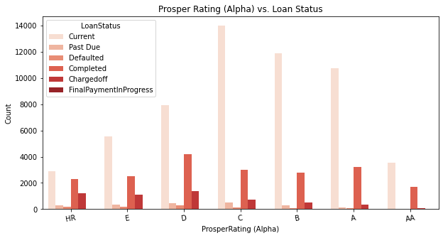

```python
#plot bivariate analysis of two qualitative variables
fig, ax = plt.subplots(figsize=(10,5))
#ax.set(yscale="log")
sb.countplot(data = loan_data, x = 'ProsperRating (Alpha)', ax=ax, hue = 'LoanStatus', palette = 'Reds')
plt.xticks(rotation=10)
plt.ylabel('Count')
plt.title('Prosper Rating (Alpha) vs. Loan Status');
```

### Did you observe any interesting relationships between the other features (not the main feature(s) of interest)?

> No

## Multivariate Exploration

> Create plots of three or more variables to investigate your data even further. Make sure that your investigations are justified, and follow from your work in the previous sections.

#### What is the effect of collateral (home owner) and income range on the Borrower's APR?

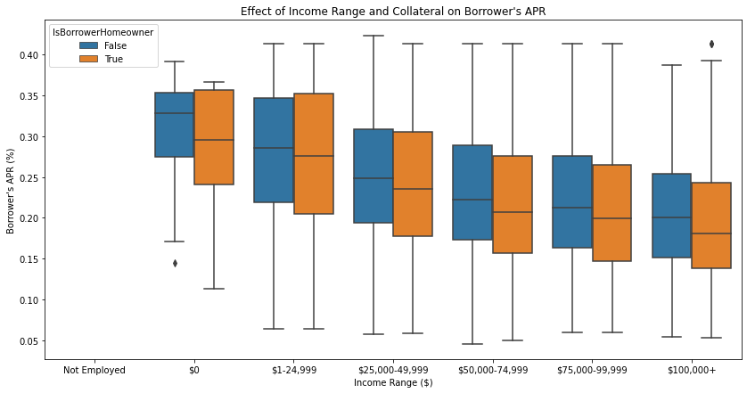

```python
#plot boxplot
plt.figure(figsize = [14,7])
sb.boxplot(data = loan_data, x = 'IncomeRange', y = 'BorrowerAPR', hue = 'IsBorrowerHomeowner')

plt.ylabel("Borrower's APR (%)")
plt.xlabel('Income Range ($)')
plt.title("Effect of Income Range and Collateral on Borrower's APR");
```

#### What is the effect of Prosper Rating and Loan Terms on Borrower's APR?

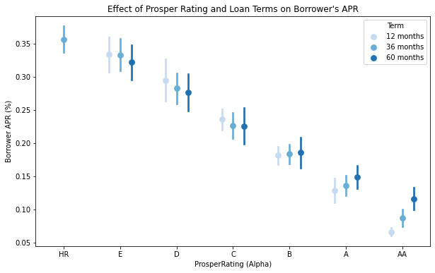

```python
#plot pointplot
fig = plt.figure(figsize = [10,6])
ax = sb.pointplot(data = loan_data, x = 'ProsperRating (Alpha)', y = 'BorrowerAPR', hue = 'Term',
           palette = 'Blues', linestyles = '',dodge = 0.4, ci='sd')

plt.ylabel('Borrower APR (%)')
plt.title("Effect of Prosper Rating and Loan Terms on Borrower's APR");
```

It can be identified that higher prosper ratings are associated with lower borrower's APR. Additionally, for higher grades such as A and AA, the APR tend to increase with longer loan terms compared with that of the lower ratings (such as C and D).

#### What is the effect of Borrower's employment status and loan status on Borrower's APR?

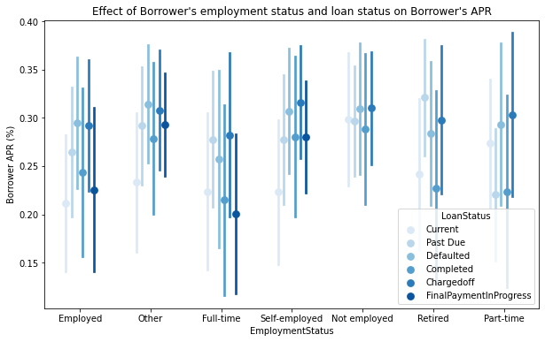

```python
#plot pointplot
fig = plt.figure(figsize = [10,6])
ax = sb.pointplot(data = loan_data, x = 'EmploymentStatus', y = 'BorrowerAPR', hue = 'LoanStatus',
           palette = 'Blues', linestyles = '',dodge = 0.4, ci='sd')

plt.ylabel('Borrower APR (%)')
plt.title("Effect of Borrower's employment status and loan status on Borrower's APR");
```

It can be identified that the unemployed borrowers (regardless of loan status) have higher APR compared to employed and full-time borrowers. Also, the employed and full-time borrowers that have either completed their loan payment or have the final payment in progress tend to have lower APR (%).

### Talk about some of the relationships you observed in this part of the investigation. Were there features that strengthened each other in terms of looking at your feature(s) of interest?

> It can be identified that higher prosper ratings are associated with lower borrower's APR. That is, loans with prosper rating of AA should have the lowest range of Annual Percentage Rates (APRs) of borrowers while loans with rating of HR should have the highest range of APRs

### Were there any interesting or surprising interactions between features?

> The multivariate exploration revealed that both higher income ranges and owning a home (that serve as collateral) are stringent requirements that affect the borrower's annual percentage rate.

## Conclusions

> **Reflection**: This exploratory part of the project involved assessing and cleaning the data before performing data exploration. The exploration included:
> 1. Univariate analysis to investigate distribution of feature(s) of interest.
> 2. Bivariate analysis to investigate different relationships between two variables.
> 3. Multivariate analysis to investigate relationships among three or more variables.

> **Summary of Findings**: From the exploratory analysis, it was discovered that:
> - The main factors associated with the Borrower's APR related to original loan amount are: *borrower's income range*, *prosper rating*, *collateral* and *prosper risk score*.
> - The unemployed borrowers (regardless of loan status) have higher APR compared to employed and full-time borrowers. On the other hand, the employed and full-time borrowers that have either completed their loan payment or have the final payment in progress tend to have lower APR (%).